# Hotspot identification using a relative frequency distribution approach

PJ Bouchet

2019-01-18

This small vignette illustrates the use of custom functions for identifying ‘hotspots’ in a spatial variable of interest.

The code is based on the frequency distribution approach proposed by Bartolino et al. (2011)[^1] and applied in Bouchet et al. (2017).[^2]

The required libraries and options are specified below.

```r
library(fANCOVA)
library(raster)
library(virtualspecies)
library(tidyverse)

options(tibble.width = Inf)  # All tibble columns shown
options(pillar.neg = FALSE)  # No colouring negative numbers
options(pillar.subtle = TRUE)
options(pillar.sigfig = 4)
```

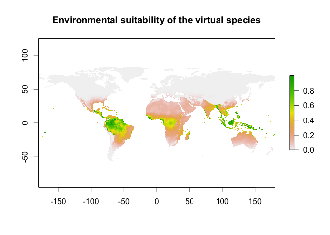

```r
# Downloads WorldClim data
worldclim <- getData("worldclim", var = "bio", res = 10)

# Gaussian functions of bio1 and bio12
my.parameters <- formatFunctions(bio1 = c(fun = "dnorm", mean = 250, sd = 50),
    bio12 = c(fun = "dnorm", mean = 4000, sd = 2000))

# Generates simulated species distributions
simsp <- generateSpFromFun(raster.stack = worldclim[[c("bio1", "bio12")]], parameters = my.parameters,
    plot = TRUE)
```

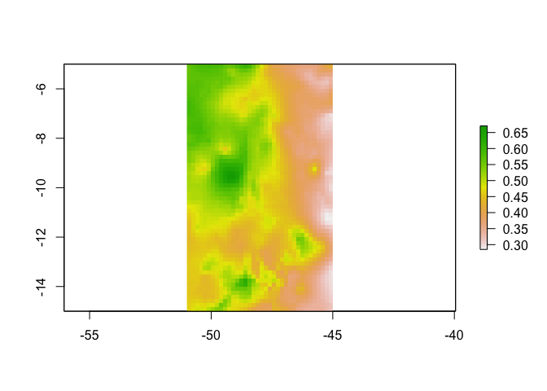

```r
# For the sake of the example only extracts a small portion of that
# distribution eg from South America
simdist <- raster::crop(x = simsp$suitab.raster, y = as(extent(c(-51, -45, -15,
    -5)), "SpatialPolygons"))

plot(simdist)
```

```r
# Turns the raster into a data.frame object and manipulates values
dat <- raster::as.data.frame(simdist, xy = T)
dat <- dat %>% purrr::set_names(., c("longitude", "latitude", "z"))
dat$z = round(dat$z * 100, 0)
```

Next we define custom functions to calculate the cumulative relative frequency distribution function CRFD (as described in the Bartolino paper)

```r
no.cumul <- function(data, value) {
    return(length(data[data < value]))
}

bartolino <- function(df, var.name) {

    # Converts var.name to a string
    var.name <- deparse(substitute(var.name))

    # Calculates x-axis [x = z / zm] and y-axis [y = M(x)/n] values
    df <- df %>% mutate_(x = paste(var.name, "/max(", var.name, ")"))

    allx <- df %>% pull(x)

    df <- df %>% rowwise %>% mutate(y = no.cumul(allx, x)/nrow(df)) %>% ungroup()

    return(df)
}  # End function
```

These functions can be applied to the data.

```r
dat.bart <- bartolino(df = dat, var.name = z)
```

Additional functions are needed to determine the highest x-value corresponding to a 45 degree tangent to the predicted loess curve.

```r
find.bartolino <- function(loess.predictions) {

    for (p in 3:(length(loess.predictions) - 1)) {
        slope.curve <- (loess.predictions[p + 1] - loess.predictions[p - 1])/(loess.x[p +
            1] - loess.x[p - 1])
        if (slope.curve >= 1) {
            barto.x <- loess.x[p]
            break
        }
    }
    return(barto.x)
}  # End function

find.bartolino.y <- function(loess.predictions) {

    for (p in 3:(length(loess.predictions) - 1)) {
        slope.curve <- (loess.predictions[p + 1] - loess.predictions[p - 1])/(loess.x[p +
            1] - loess.x[p - 1])
        if (slope.curve >= 1) {
            barto.y <- loess.predictions[p]
            break
        }
    }
    return(barto.y)
}  # End function
```

A LOESS model can be fitted to the CRFD points, and the x-value cutoff identified from the resulting predictions.

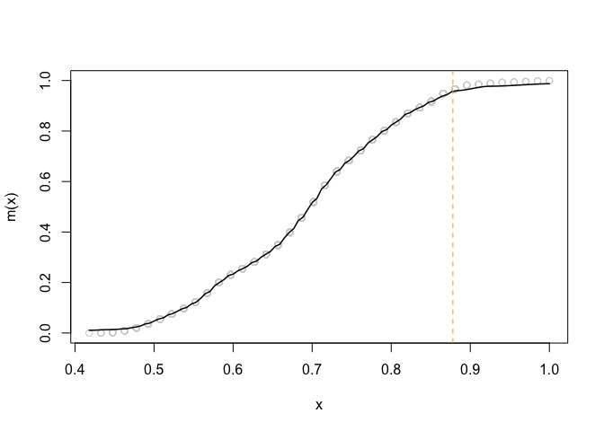

```r
# LOESS smoothing - with automated span selection based on AICc or GCV The
# degree of smoothing can also be selected manually using user.span

loess.x <- rev(seq(0, 1, 0.001))
loessmod.n <- fANCOVA::loess.as(dat.bart$x, dat.bart$y, degree = 0, criterion = c("aicc",
    "gcv")[1], user.span = NULL, plot = T)

lo.preds.n <- predict(loessmod.n, loess.x)

xbest <- find.bartolino(lo.preds.n)
ybest <- find.bartolino.y(lo.preds.n)
abline(v = xbest, col = "orange", lty = 2)
```

Finally, hotspots are simply those sites with an x value higher than the threshold.

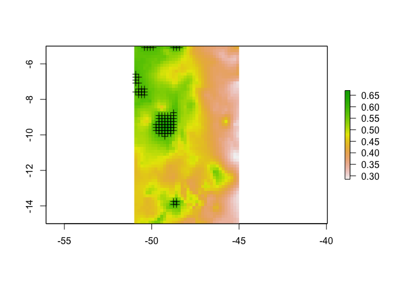

```r
dat.hot <- dat.bart %>% filter(x >= xbest)

# Converts to SpatialPoints df
hot.pts <- dat.hot %>% dplyr::select(longitude, latitude, z) %>% SpatialPointsDataFrame(coords = cbind(.$longitude,
    .$latitude), data = .)

# Visualisation
plot(simdist)
plot(hot.pts, add = T)
```

[^1]: Bartolino V, Maiorano L, Colloca F. 2011. A frequency distribution approach to hotspot identification. Population Ecology, 53(2): 351-359
[^2]: Bouchet et al. 2017. Continental-scale hotspots of pelagic fish abundance inferred from commercial catch records. Global Ecology and Biogeography, 26(10): 1098-1111.